# 計量経済学応用

# 複合仮説の検定

## データの準備

```r
myd <- read_csv("data/6_1_income.csv")
```

## 回帰モデルと推定

以下のミンサー方程式を推定する。
$$\ln(賃金) = \beta_0 + \beta_1 修学年数　+ \beta_2 就業可能年数 + \beta_3 (修行可能年数)^2 + U$$
ただし、Uは誤差項である。

このモデルの係数を、Rで推定する。

```r
fit_mincer <- lm(lincome ~ yeduc + exper + exper2, data = myd)
summary(fit_mincer)
```

```
##
## Call:
## lm(formula = lincome ~ yeduc + exper + exper2, data = myd)
##
## Residuals:
##     Min      1Q  Median      3Q     Max
## -4.0389 -0.3214  0.1681  0.5124  2.1326
##
## Coefficients:
##               Estimate Std. Error t value Pr(>|t|)
## (Intercept)  2.4855019  0.1107823   22.44   <2e-16
## yeduc        0.1175467  0.0070603   16.65   <2e-16
## exper        0.1961736  0.0074935   26.18   <2e-16
## exper2      -0.0063811  0.0003162  -20.18   <2e-16
##
## Residual standard error: 0.7983 on 4295 degrees of freedom
## Multiple R-squared:  0.2066, Adjusted R-squared:  0.206
## F-statistic: 372.8 on 3 and 4295 DF,  p-value: < 2.2e-16
```

これまでは、「修学年数は賃金に影響するか」のような疑問に答えるため、次のような仮説を検定してきた。

- 帰無仮説: $\beta_1 = 0$
- 対立仮説: $\beta_1 \neq 0$

この例では、修学年数 yeduc の係数の$p$値が $2\times 10^{-16}$ 未満なので、有意水準5パーセントで上の帰無仮説は棄却される。

## 複合仮説とF検定

これに対し、「ミンサー方程式に就業可能年数とその二乗という2つの変数を加えることに意味はあるか」という疑問をもったとしよう。この疑問に答えるためには、次のような仮説が必要になる。

- 帰無仮説: $\beta_2 = \beta_3 = 0$
- 対立仮説: $\beta2$ と $\beta_3$ のうち少なくとも一方は0でない

このように複数の母数（パラメタ）について同時に考える仮説を**複合仮説** と呼ぶ。複合仮説の検定には$F$分布の特徴を利用した$F$検定が使われる。

帰無仮説が正しい場合、
$$\ln(賃金) = \beta_0 + \beta_1 修学年数　 + U$$
となるはずである。こんモデル（null モデル）を推定する。

```r
fit_mincer_null <- lm(lincome ~ yeduc, data = myd)
summary(fit_mincer_null)
```

```
##
## Call:
## lm(formula = lincome ~ yeduc, data = myd)
##
## Residuals:
##     Min      1Q  Median      3Q     Max
## -3.6801 -0.2897  0.2211  0.5496  2.2060
##
## Coefficients:
##             Estimate Std. Error t value Pr(>|t|)
## (Intercept) 4.309553   0.100755  42.772   <2e-16
## yeduc       0.070772   0.007204   9.824   <2e-16
##
## Residual standard error: 0.8861 on 4297 degrees of freedom
## Multiple R-squared:  0.02197,    Adjusted R-squared:  0.02174
## F-statistic: 96.52 on 1 and 4297 DF,  p-value: < 2.2e-16
```

このnull モデルと先ほど推定したモデル（model_mincer; ミンサー方程式）に違いがあるかどうか検定したい。そのために$F$検定を行う。

```r
length(fit_mincer$fitted.values)
```

```
## [1] 4299
```

```r
fit_mincer$df.residual
```

```
## [1] 4295
```

```r
SSR_null <- sum((fit_mincer_null$residuals)^2)
SSR_alt <- sum((fit_mincer$residuals)^2)
q <- 2
(F_mincer <- ((SSR_null - SSR_alt) / q) / (SSR_alt / fit_mincer$df.residual))
```

```
## [1] 499.7542
```

検定に使う$F$統計量は、499.75 である。

**帰無仮説が正しいとすると**、この値は、自由度 ($q$, $n-k-1$) の$F$分布にしたがうことが知られている。この特徴を利用して、検定を実施する。$t$分布とは異なり、$F$分布は0以上の値しかとらない。よって、片側検定を実施する。自由度が (2, 4295) の$F$分布は、以下の確率密度をもつ。

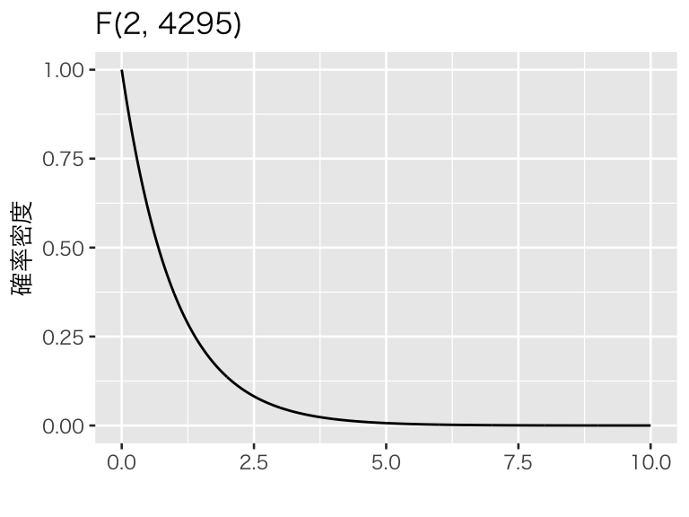

```r
df <- tibble(x = seq(from = 0, to = 10, length.out = 1000)) %>%
  mutate(dens = df(x, df1 = 2, df2 = 4295))
fdens <- ggplot(df, aes(x = x, y = dens)) +
  geom_line() +
  labs(x = "", y = "確率密度", title = "F(2, 4295)")
plot(fdens)
```

この分布で、上で計算した検定統計量の数値以上の値を取る確率があらかじめ決めた有意水準を下回るとき、帰無仮説を棄却する。有意水準を5%にする場合、この分布で$F$値が499.75以上になる確率が 0.05 未満なら、帰無仮説を棄却する。

上の図から、$F$値が499.75 以上になる確率はほぼゼロになると思われるが、念のために計算してみよう。

```r
pf(F_mincer, df1 = 2, df2 = 4295, lower.tail = FALSE)
```

```
## [1] 7.461626e-196
```

この値はほぼゼロであり、0.05よりは小さい。よって、5%の有意水準で帰無仮説は棄却される。

同様に、$F$検定の臨界値と検定統計量を比較することによって検定を行うこともできる。自由度 (2, 4295) の$F$分布の95パーセンタイル地点は、

```r
qf(p = 0.95, df1 = 2, df2 = 4295)
```

```
## [1] 2.997823
```

である。上で計算した検定統計量は 499.75 であり、この臨界値よりも大きいので、5%の有意水準で帰無仮説は棄却される。

以上の結果から、重回帰分析に就業可能年数とその二乗という二つの項を加えることは**統計的には**意味があることがわかる。

# 演習

課題3で分析した教科書の練習問題7-Bと7-Cについて、

- 交差項の効果を可視化してみよう
- $F$検定を実行してみよう

# 参考

これまで勉強しきたこと：

- [単回帰分析](http://yukiyanai.github.io/jp/classes/econometrics2/contents/R/linear-regression-1.html)
- [回帰分析の基礎](http://yukiyanai.github.io/jp/classes/econometrics1/contents/R/intro-to-regression.html)
- [変数変換](http://yukiyanai.github.io/jp/classes/econometrics1/contents/R/linear-regression.html)
- [回帰分析のシミュレーション](http://yukiyanai.github.io/jp/classes/econometrics2/contents/R/linear-regression-simulation1.html)
- [欠落変数バイアスのシミュレーション](http://yukiyanai.github.io/jp/classes/econometrics2/contents/R/omitted-variable-bias.html)
- [分析結果の提示法](http://yukiyanai.github.io/jp/classes/econometrics2/contents/R/linear-regression-4.html)

授業の内容に戻る